# Incarceration in Washington

## Graph 2

[figure not shown]

This graph was included to show how the total number of incarcerated people in Washington changed over time. From this graph you see that from about 1980 to 2010 the amount of incarcerated people increased pretty rapidly. You also see that in 2010 the amount of incarcerated people dropped and that leveled out to where it has been since then.

## Map

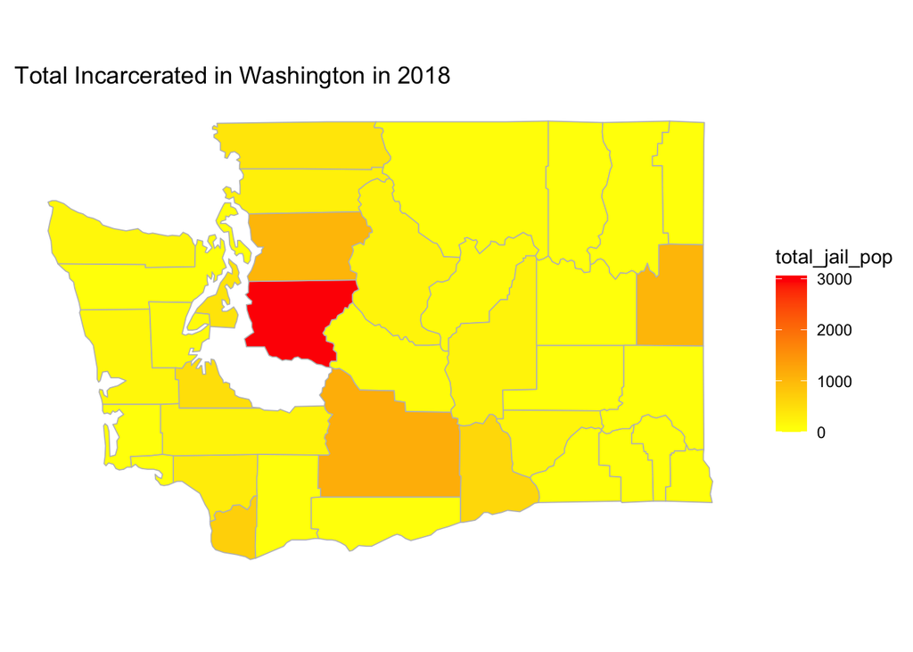

This map was included to show which Counties in Washington have the most people incarcerated. The map shows that while most counties have a pretty similar amount of people incarcerated, King County has significantly more than any other county.